# Almond Yield Anomalies

Author

Jackson Coldiron and Kaitlin Castor

## Introduction

This project implements a simplified model of almond yield anomaly in response to climate variables, adapted from the transfer functions developed by Lobell et al. (2006). The model estimates annual yield anomalies using daily climate data, specifically focusing on minimum and maximum temperatures and precipitation. The goal is to understand how year-to-year climate variability impacts almond productivity in California and to replicate expected yield patterns based on historical data.

## Data

The climate dataset (clim.txt) contains daily weather observations including:

day: Day of the month

month: Calendar month

year: Calendar year

wy: Water year

tmax_c: Daily maximum temperature (°C)

tmin_c: Daily minimum temperature (°C)

precip: Daily precipitation (mm)

Other parameters: - location: California - time frame: 1989-2010 - yield model adjusted R**2 = 0.88 - yield model developed from monthly averages aggregated to the state scale from 1980 - 2003 records. This excludes factors such as extreme heat events or spatial variations.

## Conceptual Model

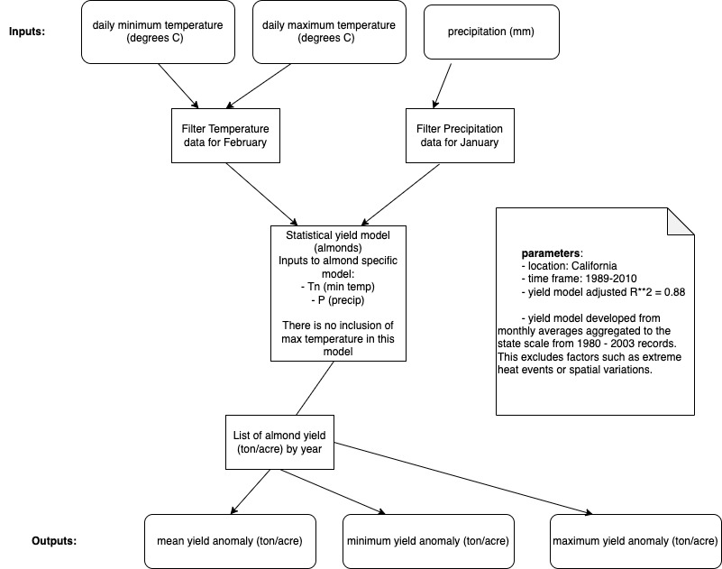

```r
knitr::include_graphics(here::here("data", "assignment2_conceptualmodel.jpg"))
```

## Data Processing

```r
# Import libraries
library(tidyverse)
library(here)
library(dplyr)
library(purrr)
library(tibble)
library(knitr)
library(kableExtra)

# Import data and function
climate_data_raw <- read.table(here("data", "clim.txt"), header = TRUE, sep = "", quote = "\"")

source(here("R", "almond_yield_function.R"))

# Summarize inputs by year for model
yearly_anomalies <- climate_data_raw |>
  group_by(year) |>
  summarise(
    Tn = mean(tmin_c[month == 2], na.rm = TRUE),
    Tx = mean(tmax_c[month == 2], na.rm = TRUE),
    P = sum(precip[month == 1], na.rm = TRUE)) |>
    drop_na()
```

## Function Implementation

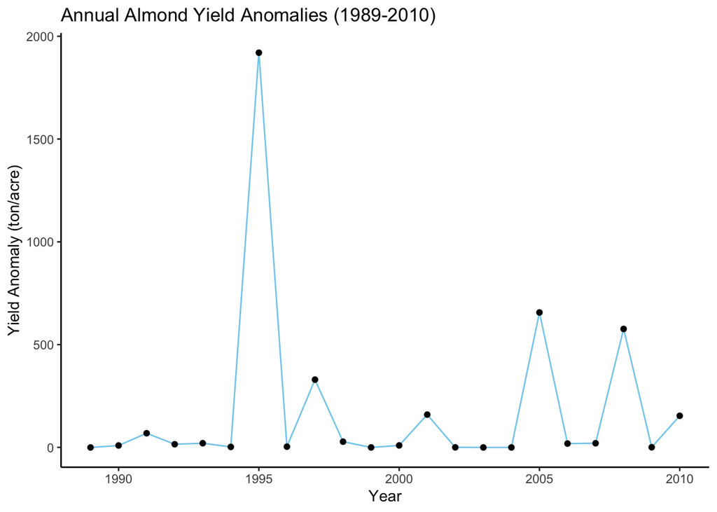

```r
# Apply the function to each year
yearly_anomalies <- yearly_anomalies |>
  group_by(year) |>
  summarise(
    yield_anomaly = almond_yield(Tn, P)
  )

# Output Statistics
yield_stats <- yearly_anomalies |>
  summarise(
    max_yield = max(yield_anomaly),
    min_yield = min(yield_anomaly),
    mean_yield = mean(yield_anomaly)
  )

yield_stats <- yield_stats |>
  rename(
    `Max Yield` = max_yield,
    `Min Yield` = min_yield,
    `Mean Yield` = mean_yield
  )

# Plot results
yearly_anomalies |>
  ggplot(aes(x = year, y = yield_anomaly)) +
  geom_line(color = "skyblue") +
  geom_point() +
  labs(
    title = "Annual Almond Yield Anomalies (1989-2010)",
    x = "Year",
    y = "Yield Anomaly (ton/acre)"
  ) +
  theme_classic()
```

## Results

```r
# Display with kable
yield_stats |>
  kable(digits = 4, caption = "Annual Almond Yield Anomaly Summary (ton/acre)") |>
  kable_styling(font_size = 12, full_width = FALSE)
```

Annual Almond Yield Anomaly Summary (ton/acre)

| Max Yield | Min Yield | Mean Yield |
| --- | --- | --- |
| 1919.981 | -0.3552 | 181.4453 |